# TidyTuesday: Shakespeare Analysis

This is my data analysis of the datasets on shakespeare for the tidytuesday of 9/17. First let’s set up the packages I will be using for this analysis.

```r
install.packages("tidytuesdayR")
library(tidytuesdayR)
install.packages("tidyverse")
library(tidyverse)
```

```r
install.packages("ggplot2")
library(ggplot2)
install.packages("SnowballC")
library(SnowballC)
install.packages("wordcloud")
library(wordcloud)
install.packages("RColorBrewer")
library(RColorBrewer)
install.packages("tidytext")
library(tidytext)
install.packages("tm")
library(tm)
```

Now let’s pull the datasets from the tidytuesday package.

```r
tt_gh <- tt_load_gh("2024-09-17")
```

```
## ---- Compiling #TidyTuesday Information for 2024-09-17 ----
## --- There are 3 files available ---
```

Now I see that it only finds three of the datasets, I will manually add the rest and load all of them.

```r
hamlet <- tt_download_file(tt_gh, "hamlet.csv")
macbeth <- tt_download_file(tt_gh, "macbeth.csv")
romeo_juliet <- tt_download_file(tt_gh, "romeo_juliet.csv")
julius_caesar <- read_csv("julius_caesar.csv")
othello <- read_csv("othello.csv")
metadata <- read_csv("metadata.csv")
```

Now then we will begin the analysis. I want to first look at which character had the most lines for each play. My theory is that the main characters should have the most line in their given play.

First I have to set the dataframes that will be used to count the amount of line per person.

```r
# Creating dataframes with the all the characters and their line counts
line_count_hamlet <- hamlet %>%
  group_by(character) %>%
  summarize(line_count = n())
line_count_hamlet <- arrange(line_count_hamlet, -line_count)

line_count_macbeth <- macbeth %>%
  group_by(character) %>%
  summarize(line_count = n())
line_count_macbeth <- arrange(line_count_macbeth, -line_count)

line_count_romjul <- romeo_juliet %>%
  group_by(character) %>%
  summarize(line_count = n())
line_count_romjul <- arrange(line_count_romjul, -line_count)

line_count_jc <- julius_caesar %>%
  group_by(character) %>%
  summarize(line_count = n())
line_count_jc <- line_count_jc <- arrange(line_count_jc, -line_count)

line_count_othello <- othello %>%
  group_by(character) %>%
  summarize(line_count = n())
line_count_othello <- arrange(line_count_othello, -line_count)
```

Now let’s view the dataframes as well as graph them.

```r
knitr::kable(line_count_hamlet[,1:2], format="html")
```

| character | line_count |
| --- | --- |
| Hamlet | 1495 |
| King Claudius | 546 |
| Lord Polonius | 355 |
| Horatio | 289 |
| Laertes | 206 |
| [stage direction] | 206 |
| Ophelia | 173 |
| Queen Gertrude | 157 |
| Ghost | 95 |
| First Clown | 94 |
| Rosencrantz | 93 |
| Marcellus | 62 |
| First Player | 52 |
| Guildenstern | 52 |
| Osric | 48 |
| Player King | 44 |
| Bernardo | 38 |
| Player Queen | 30 |
| Prince Fortinbras | 27 |
| Gentleman | 24 |
| Voltimand | 22 |
| Second Clown | 18 |
| Reynaldo | 15 |
| First Priest | 13 |
| Captain | 12 |
| Francisco | 10 |
| Lord | 7 |
| First Ambassador | 6 |
| Lucianus | 6 |
| First Sailor | 5 |
| Messenger | 5 |
| All | 4 |
| Danes | 3 |
| Prologue | 3 |
| Guildenstern: | 1 |
| Servant | 1 |

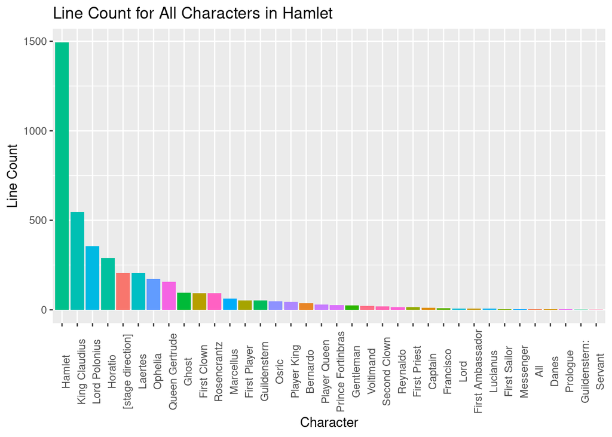

```r
ggplot(data = line_count_hamlet, aes(y=line_count,x=reorder(character, -line_count)))+geom_bar(stat='identity', aes(fill=character))+labs(title="Line Count for All Characters in Hamlet",y="Line Count", x="Character")+theme(legend.position="none", axis.text.x = element_text(angle = 90))
```

```r
knitr::kable(line_count_macbeth[,1:2], format="html")
```

| character | line_count |
| --- | --- |
| Macbeth | 717 |
| Lady Macbeth | 265 |
| Malcolm | 212 |
| Macduff | 180 |
| [stage direction] | 169 |
| Ross | 135 |
| Banquo | 113 |
| Lennox | 74 |
| Duncan | 70 |
| First Witch | 62 |
| Porter | 46 |
| Doctor | 45 |
| Lady Macduff | 41 |
| Hecate | 39 |
| Sergeant | 35 |
| First Murderer | 30 |
| Siward | 30 |
| Second Witch | 27 |
| Third Witch | 27 |
| All | 24 |
| Gentlewoman | 23 |
| Messenger | 23 |
| Angus | 21 |
| Lord | 21 |
| Son | 20 |
| Second Murderer | 15 |
| Menteith | 12 |
| Caithness | 11 |
| Old Man | 11 |
| Donalbain | 10 |
| Third Murderer | 8 |
| Young Siward | 7 |
| Servant | 5 |
| Seyton | 5 |
| Third Apparition | 5 |
| Second Apparition | 4 |
| Lords | 3 |
| Both Murderers | 2 |
| First Apparition | 2 |
| Fleance | 2 |
| Attendant | 1 |
| Soldiers | 1 |

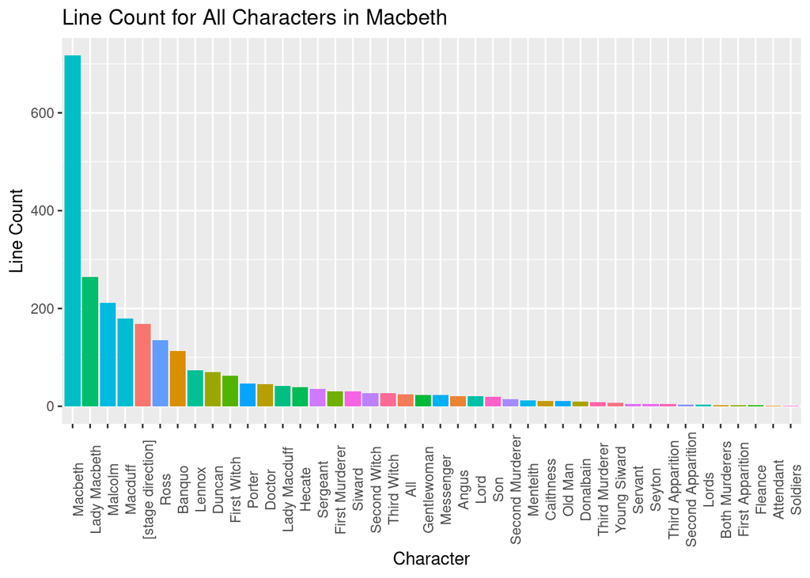

```r
ggplot(data = line_count_macbeth, aes(y=line_count,x=reorder(character, -line_count)))+geom_bar(stat='identity', aes(fill=character))+labs(title="Line Count for All Characters in Macbeth",y="Line Count", x="Character")+theme(legend.position="none", axis.text.x = element_text(angle = 90))
```

```r
knitr::kable(line_count_romjul[,1:2], format="html")
```

| character | line_count |
| --- | --- |
| Romeo | 612 |
| Juliet | 544 |
| Friar Laurence | 351 |
| Nurse | 281 |
| Capulet | 273 |
| Mercutio | 261 |
| [stage direction] | 189 |
| Benvolio | 160 |
| Lady Capulet | 115 |
| Prince | 76 |
| Paris | 70 |
| Montague | 41 |
| Tybalt | 36 |
| Peter | 33 |
| Balthasar | 32 |
| Sampson | 31 |
| Chorus | 28 |
| Servant | 23 |
| Gregory | 20 |
| First Watchman | 19 |
| Friar John | 13 |
| Second Servant | 12 |
| First Servant | 10 |
| First Musician | 9 |
| Page | 9 |
| Apothecary | 7 |
| First Citizen | 6 |
| Abraham | 5 |
| Second Musician | 4 |
| Lady Montague | 3 |
| Second Capulet | 3 |
| Third Watchman | 3 |
| Musician | 1 |
| Second Watchman | 1 |
| Third Musician | 1 |

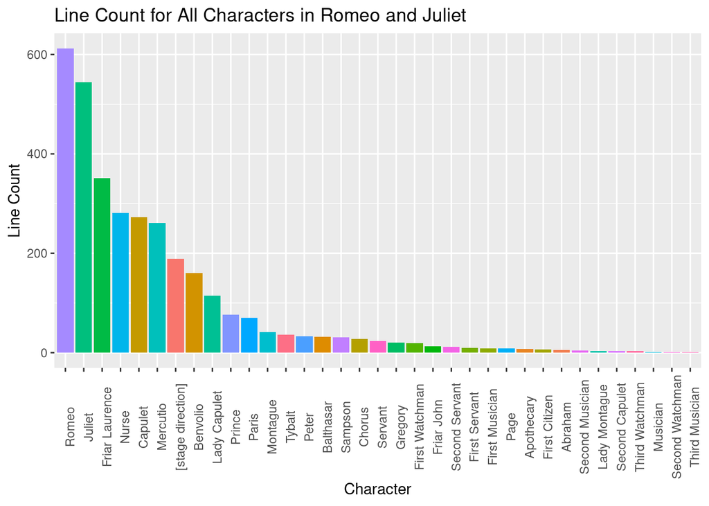

```r
ggplot(data = line_count_romjul, aes(y=line_count,x=reorder(character, -line_count)))+geom_bar(stat='identity', aes(fill=character))+labs(title="Line Count for All Characters in Romeo and Juliet",y="Line Count", x="Character")+theme(legend.position="none", axis.text.x = element_text(angle = 90))
```

```r
knitr::kable(line_count_jc[,1:2], format="html")
```

| character | line_count |
| --- | --- |
| Brutus | 728 |
| Cassius | 525 |
| Antony | 329 |
| [stage direction] | 152 |
| Caesar | 135 |
| Casca | 133 |
| Portia | 92 |
| Octavius | 46 |
| Decius Brutus | 44 |
| Messala | 39 |
| Lucius | 33 |
| Marullus | 31 |
| Titinius | 31 |
| Servant | 30 |
| Calpurnia | 27 |
| Lucilius | 26 |
| Flavius | 24 |
| First Citizen | 22 |
| Third Citizen | 22 |
| Second Citizen | 21 |
| Fourth Citizen | 20 |
| Artemidorus | 19 |
| Cinna | 18 |
| Soothsayer | 18 |
| Metellus Cimber | 17 |
| Pindarus | 17 |
| Second Commoner | 16 |
| Ligarius | 15 |
| Cinna The Poet | 14 |
| All | 10 |
| Clitus | 10 |
| Cicero | 9 |
| Trebonius | 9 |
| Cato | 8 |
| Poet | 7 |
| Strato | 7 |
| First Soldier | 5 |
| Claudius | 4 |
| Lepidus | 4 |
| Messenger | 4 |
| Varro | 4 |
| Dardanius | 3 |
| Ghost | 3 |
| Volumnius | 3 |
| Citizens | 2 |
| Popilius | 2 |
| Publius | 2 |
| Second Soldier | 2 |
| Several Citizens | 2 |
| This Way Will I | 2 |
| First Commoner | 1 |
| Third Soldier | 1 |

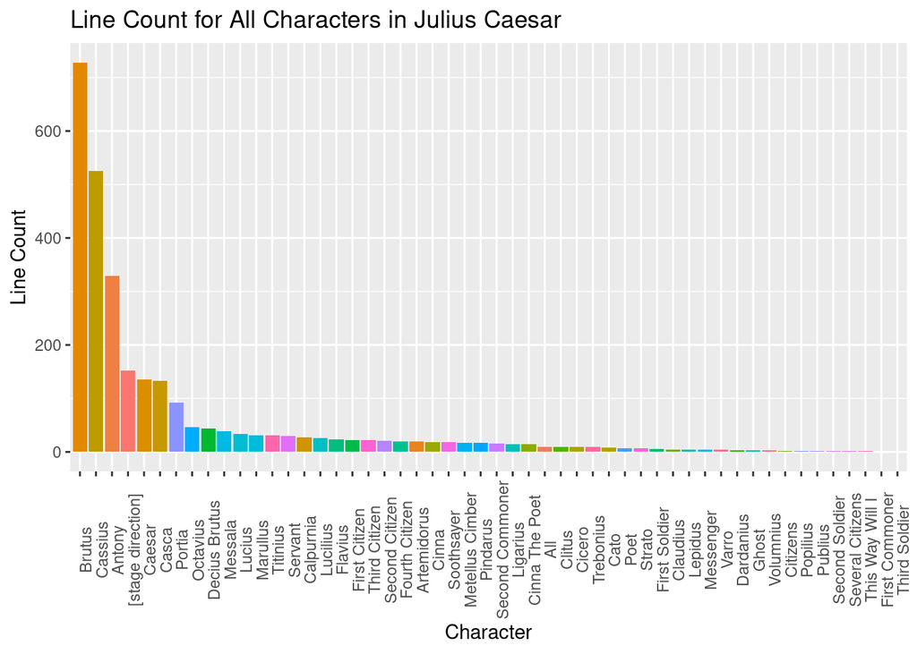

```r
ggplot(data = line_count_jc, aes(y=line_count,x=reorder(character, -line_count)))+geom_bar(stat='identity', aes(fill=character))+labs(title="Line Count for All Characters in Julius Caesar",y="Line Count", x="Character")+theme(legend.position="none", axis.text.x = element_text(angle = 90))
```

```r
knitr::kable(line_count_othello[,1:2], format="html")
```

| character | line_count |
| --- | --- |
| Iago | 1099 |
| Othello | 887 |
| Desdemona | 388 |
| Cassio | 277 |
| Emilia | 245 |
| [stage direction] | 185 |
| Brabantio | 139 |
| Roderigo | 114 |
| Lodovico | 76 |
| Duke Of Venice | 71 |
| Montano | 61 |
| Bianca | 34 |
| Gratiano | 32 |
| Clown | 27 |
| First Senator | 26 |
| Third Gentleman | 17 |
| Herald | 12 |
| Second Gentleman | 12 |
| Messenger | 9 |
| First Musician | 5 |
| First Officer | 5 |
| Second Senator | 5 |
| Sailor | 4 |
| First Gentleman | 3 |
| All | 2 |
| Fourth Gentleman | 2 |
| Second Gentlemen | 2 |
| Senator | 2 |
| Gentleman | 1 |

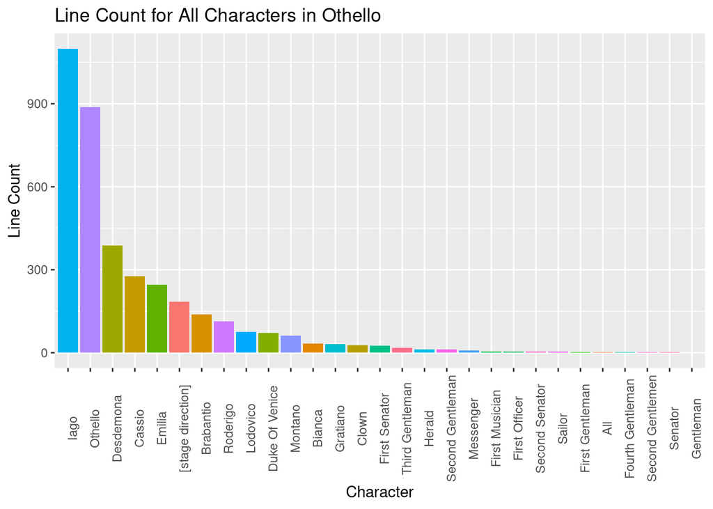

```r
ggplot(data = line_count_othello, aes(y=line_count,x=reorder(character, -line_count)))+geom_bar(stat='identity', aes(fill=character))+labs(title="Line Count for All Characters in Othello",y="Line Count", x="Character")+theme(legend.position="none", axis.text.x = element_text(angle = 90))
```

As we can see in Othello, Othello does not have the most even while being the protagonist in the play. It is the antagonist that has the most lines, Iago.

Next I want to check which acts have the most lines and which character in those acts have the most lines. Firstly I will analysis what acts has the most lines

```r
line_act_hamlet <- hamlet %>%
  group_by(act) %>%
  summarize(line_count = n())
line_act_hamlet <- arrange(line_act_hamlet, -line_count)

line_act_macbeth <- macbeth %>%
  group_by(act) %>%
  summarize(line_count = n())
line_act_macbeth <- arrange(line_act_macbeth, -line_count)

line_act_romjul <- romeo_juliet %>%
  group_by(act) %>%
  summarize(line_count = n())
line_act_romjul <- arrange(line_act_romjul, -line_count)

line_act_jc <- julius_caesar %>%
  group_by(act) %>%
  summarize(line_count = n())
line_act_jc <- arrange(line_act_jc, -line_count)

line_act_othello <- othello %>%
  group_by(act) %>%
  summarize(line_count = n())
line_act_othello <- arrange(line_act_othello, -line_count)
```

Now to view the dataframe and graph them accordingly.

```r
line_act_hamlet[,1:2]
```

| act | line_count |
| --- | --- |
| Act III | 981 |
| Act I | 944 |
| Act V | 775 |
| Act II | 773 |
| Act IV | 744 |

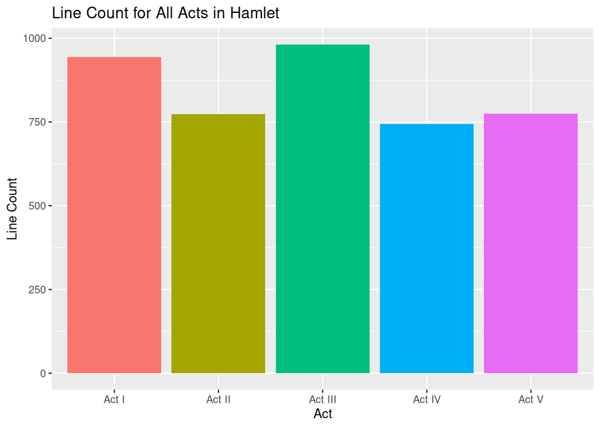

```r
ggplot(data = line_act_hamlet, aes(x=act, y=line_count))+geom_bar(stat='identity', aes(fill=act))+labs(title="Line Count for All Acts in Hamlet", x="Act", y="Line Count")+theme(legend.position="none")
```

```r
line_act_macbeth[,1:2]
```

| act | line_count |
| --- | --- |
| Act IV | 578 |
| Act I | 564 |
| Act III | 543 |
| Act V | 435 |
| Act II | 433 |

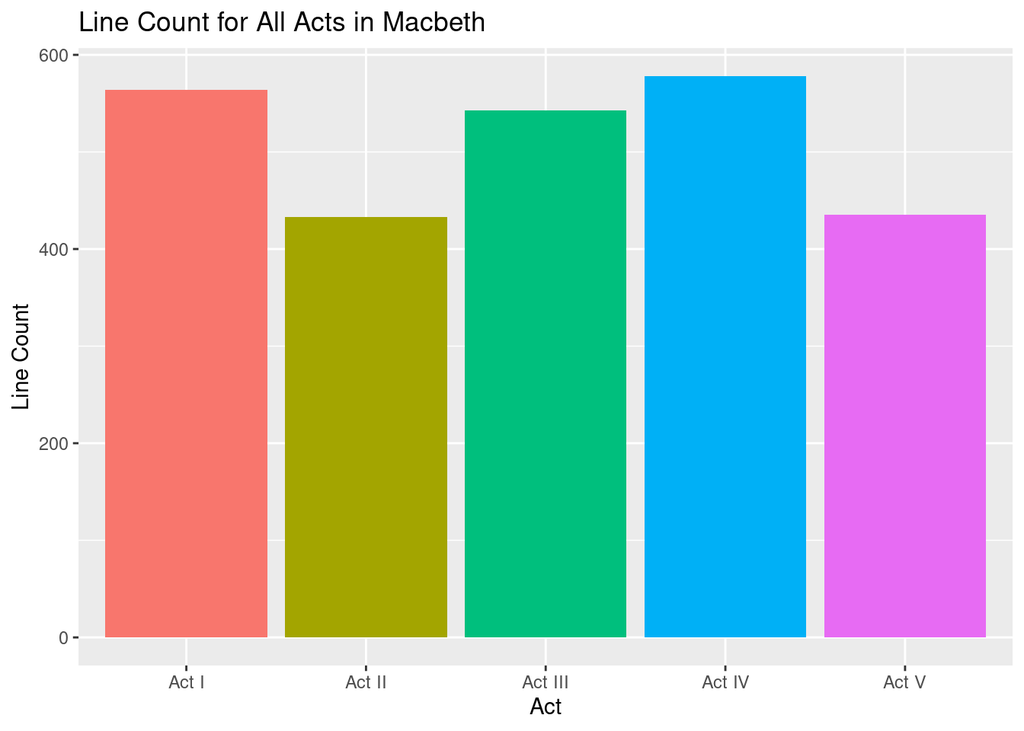

```r
ggplot(data = line_act_macbeth, aes(x=act, y = line_count))+geom_bar(stat='identity', aes(fill=act))+labs(title="Line Count for All Acts in Macbeth", x="Act", y="Line Count")+theme(legend.position="none")
```

```r
line_act_romjul[,1:2]
```

| act | line_count |
| --- | --- |
| Act III | 864 |
| Act I | 775 |
| Act II | 719 |
| Act V | 483 |
| Act IV | 441 |

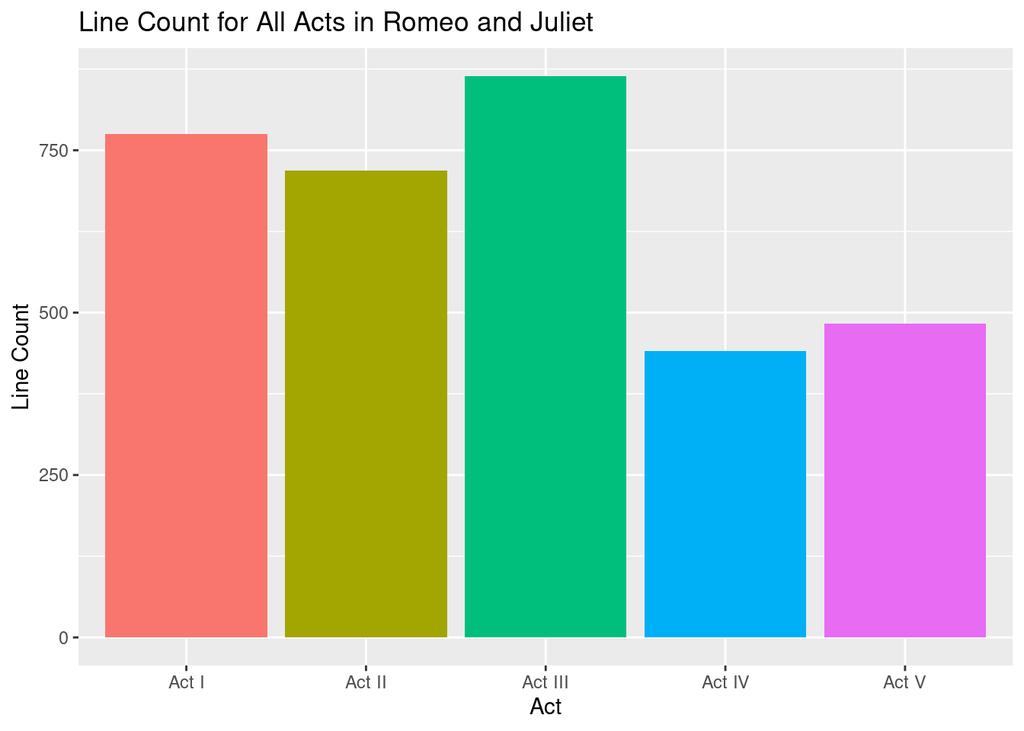

```r
ggplot(data = line_act_romjul, aes(x=act, y=line_count))+geom_bar(stat='identity', aes(fill=act))+labs(title="Line Count for All Acts in Romeo and Juliet",x="Act", y="Line Count")+theme(legend.position="none")
```

```r
line_act_jc[,1:2]
```

| act | line_count |
| --- | --- |
| Act III | 661 |
| Act I | 594 |
| Act II | 589 |
| Act IV | 484 |
| Act V | 420 |

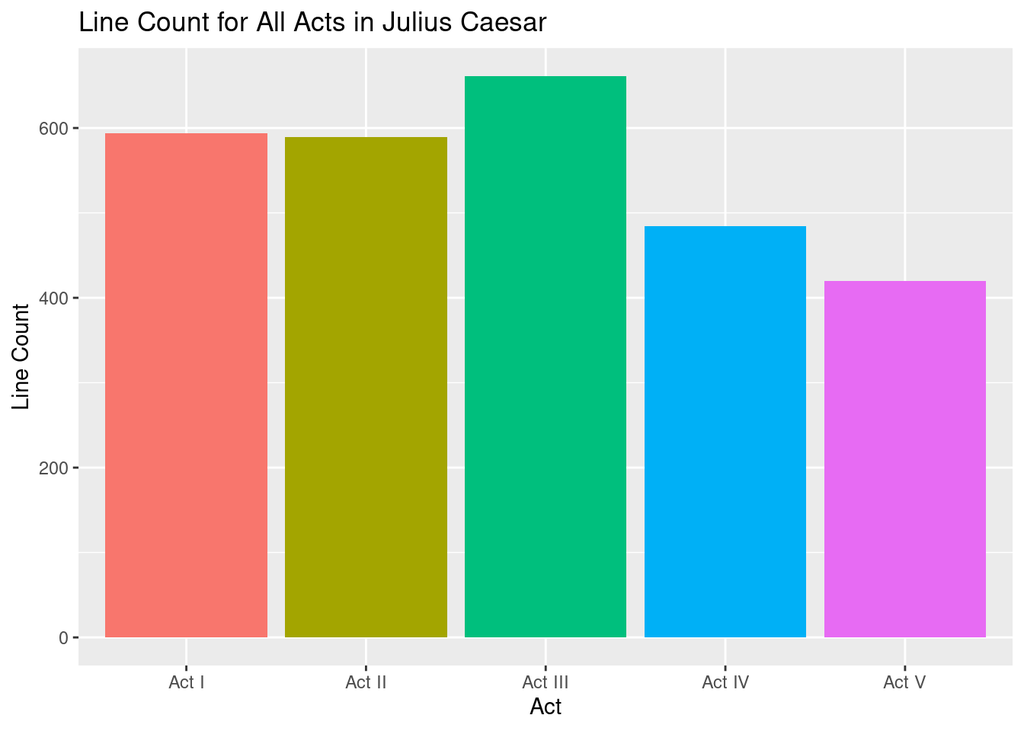

```r
ggplot(data = line_act_jc, aes(x=act, y=line_count))+geom_bar(stat='identity', aes(fill=act))+labs(title="Line Count for All Acts in Julius Caesar",x="Act", y="Line Count")+theme(legend.position="none")
```

```r
line_act_othello[,1:2]
```

| act | line_count |
| --- | --- |
| Act III | 863 |
| Act II | 782 |
| Act I | 762 |
| Act IV | 727 |
| Act V | 608 |

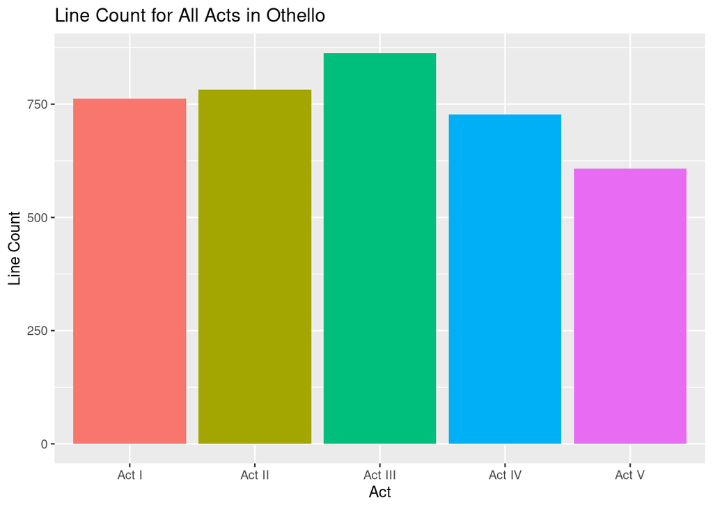

```r
ggplot(data = line_act_othello, aes(x=act, y=line_count))+geom_bar(stat='identity', aes(fill=act))+labs(title="Line Count for All Acts in Othello",x="Act", y="Line Count")+theme(legend.position="none")
```

We can see in that Act III tends to have the most lines except for Macbeth where it was Act IV that had the most lines. Now to see which character spoke the most in those scenes.

```r
act_hamlet <- hamlet %>%
  filter(act == "Act III")
fav_char_hamlet <- act_hamlet %>%
  group_by(character) %>%
  summarize(line_count = n())
fav_char_hamlet <- arrange(fav_char_hamlet, -line_count)

act_macbeth <- macbeth %>%
  filter(act == "Act IV")
fav_char_macbeth <- act_macbeth %>%
  group_by(character) %>%
  summarize(line_count = n())
fav_char_macbeth <- arrange(fav_char_macbeth, -line_count)

act_romjul <- romeo_juliet %>%
  filter(act == "Act III")
fav_char_romjul <- act_romjul %>%
  group_by(character) %>%
  summarize(line_count = n())
fav_char_romjul <- arrange(fav_char_romjul, -line_count)

act_jc <- julius_caesar %>%
  filter(act == "Act III")
fav_char_jc <- act_jc %>%
  group_by(character) %>%
  summarize(line_count = n())
fav_char_jc <- arrange(fav_char_jc, -line_count)

act_othello <- othello %>%
  filter(act == "Act III")
fav_char_othello <- act_othello %>%
  group_by(character) %>%
  summarize(line_count = n())
fav_char_othello <- arrange(fav_char_othello, -line_count)
```

Now to find which is the character will the most lines during the acts with the most lines.

```r
fav_char_hamlet[1,]
```

| character | line_count |
| --- | --- |
| Hamlet | 502 |

```r
fav_char_macbeth[1,]
```

| character | line_count |
| --- | --- |
| Malcolm | 143 |

```r
fav_char_romjul[1,]
```

| character | line_count |
| --- | --- |
| Juliet | 221 |

```r
fav_char_jc[1,]
```

| character | line_count |
| --- | --- |
| Antony | 246 |

```r
fav_char_othello[1,]
```

| character | line_count |
| --- | --- |
| Othello | 259 |

Interesting, we can see a majority of the time one of the main protagonists are mainly talking during the most vocal acts. However, two plays, Macbeth and Julius Caesar, it is Malcolm and Anthony talking the most during their plays most active act.

Looking back at the graphs with the line count for each character we can see that both of these character ranked third for their respectively plays.

Considering this, I want to look into how much these two outliers talked throughout each act to see if they talk a majority of the time in one act.

First, let’s start with Malcolm in Macbeth.

```r
malcolm_macbeth <- macbeth %>%
  filter(character == "Malcolm")

mal_act_macbeth <- malcolm_macbeth %>%
  group_by(act) %>%
  summarize(line_count = n())

malcolm_macbeth <- arrange(mal_act_macbeth, -line_count)

malcolm_macbeth
```

| act | line_count |
| --- | --- |
| Act IV | 143 |
| Act V | 39 |
| Act I | 16 |
| Act II | 14 |

Next, Antony in Julius Caesar.

```r
antony_jc <- julius_caesar %>%
  filter(character == "Antony")

ant_act_jc <- antony_jc %>%
  group_by(act) %>%
  summarize(line_count = n())
antony_jc <- arrange(ant_act_jc, -line_count)

antony_jc
```

| act | line_count |
| --- | --- |
| Act III | 246 |
| Act IV | 38 |
| Act V | 38 |
| Act I | 6 |
| Act II | 1 |

Now we can see that they did talk a majority of the talk in those acts specifically.

I want to see what they were saying using a word cloud to see what words they used the most.

Here is the word cloud from Julius Caesar using Antony’s dialouge to fill it.

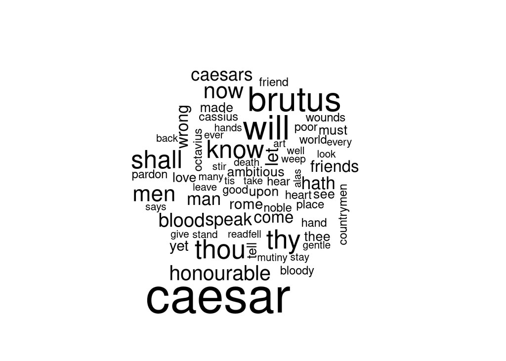

```r
lines_ant_jc <- julius_caesar %>%
  filter(character == "Antony", act == "Act III")

lines_ant <- lines_ant_jc %>%
  unnest_tokens(word, dialogue)
words_ant <- lines_ant$word

wordcloud(words_ant)
```

Now for Malcolm in Macbeth.

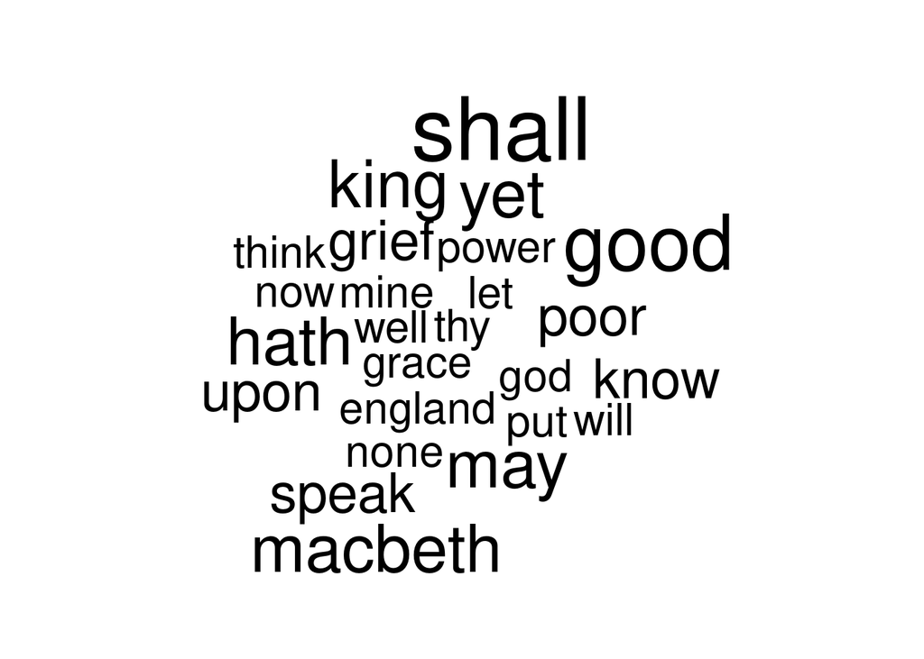

```r
lines_mal_macbeth <- macbeth %>%
  filter(character == "Malcolm", act == "Act IV")

lines_mal <- lines_mal_macbeth %>%
  unnest_tokens(word, dialogue)
words_mal <- lines_mal$word

wordcloud(words_mal)
```